# Analisis per specie

#### TABLA ANOVA 1000

```r
mods_1000 <- list(
  "Pouteria iWUE" = anova_model_iWUE,
  "δ18O" = anova_model_18O,
  "δ15N" = anova_model_15N,
  "C:N"  = anova_model_CN,
  "Clarisia iWUE " = anova_model_iWUE_cr,
  "δ18O" = anova_model_18O_cr,
  "δ15N" = anova_model_15N_cr,
  "C:N"  = anova_model_CN_cr
)

modelsummary(
  mods_1000,
  statistic = "({statistic}, p = {p.value})",
  stars = c('*' = .05, '**' = .01, '***' = .001),
  fmt = 2,
  output = "markdown",
  title = "ANOVA results for *1000 species*")
```

δ18O

δ15N

C:N

Clarisia iWUE

δ18O

δ15N

C:N

N

(0.01, p = 0.93)

(2.96, p = 0.10)

(2.15, p = 0.15)

(0.28, p = 0.60)

(3.38, p = 0.10)

(3.64, p = 0.09)

(8.85, p = 0.02)

(4.81, p = 0.06)

P

(0.04, p = 0.83)

(6.31, p = 0.02)

(0.00, p = 0.99)

(6.36, p = 0.02)

(2.60, p = 0.15)

(2.21, p = 0.18)

(1.45, p = 0.26)

(1.83, p = 0.22)

N × P

(1.33, p = 0.26)

(0.33, p = 0.57)

(0.90, p = 0.35)

(0.74, p = 0.39)

(0.02, p = 0.90)

(1.57, p = 0.24)

(3.30, p = 0.11)

(0.17, p = 0.69)

Residuals

(, p = )

(, p = )

(, p = )

(, p = )

(, p = )

(, p = )

(, p = )

(, p = )

Num.Obs.

36

36

36

36

12

12

12

11

R2

0.042

0.231

0.087

0.187

0.428

0.481

0.630

0.493

R2 Adj.

-0.048

0.159

0.001

0.111

0.214

0.287

0.491

0.276

AIC

291.9

129.1

101.1

169.7

96.6

58.2

28.5

58.1

BIC

299.8

137.1

109.0

177.6

99.0

60.6

31.0

60.1

Log.Lik.

-140.930

-59.572

-45.545

-79.826

-43.291

-24.093

-9.263

-24.057

F

0.462

3.198

1.017

2.461

1.998

2.474

4.532

2.270

RMSE

12.13

1.27

0.86

2.22

8.92

1.80

0.52

2.16

#### TABLA ANOVA 2000

```r
mods_2000 <- list(
  "Alchornea iWUE" = anova_model_iWUE_al,
  "δ18O" = anova_model_18O_al,
  "δ15N" = anova_model_15N_al,
  "C:N"  = anova_model_CN_al,
  "Myrcia iWUE " = anova_model_iWUE_m,
  "δ18O" = anova_model_18O_m,
  "δ15N" = anova_model_15N_m,
  "C:N"  = anova_model_CN_m
)
modelsummary(
  mods_2000,
  statistic = "({statistic}, p = {p.value})",
  stars = c('*' = .05, '**' = .01, '***' = .001),
  fmt = 2,
  output = "markdown",
  title = "ANOVA results for 2000 species*")
```

δ18O

δ15N

C:N

Myrcia iWUE

δ18O

δ15N

C:N

N

(0.02, p = 0.88)

(0.00, p = 0.96)

(54.10, p = <0.01)

(7.10, p = 0.01)

(1.52, p = 0.22)

(7.54, p = <0.01)

(27.43, p = <0.01)

(24.94, p = <0.01)

P

(0.81, p = 0.37)

(0.18, p = 0.68)

(0.41, p = 0.53)

(1.09, p = 0.30)

(0.63, p = 0.43)

(3.00, p = 0.09)

(0.00, p = 1.00)

(3.47, p = 0.07)

N × P

(0.43, p = 0.52)

(0.01, p = 0.92)

(0.01, p = 0.93)

(0.11, p = 0.74)

(0.72, p = 0.40)

(0.57, p = 0.46)

(8.94, p = <0.01)

(2.41, p = 0.13)

Residuals

(, p = )

(, p = )

(, p = )

(, p = )

(, p = )

(, p = )

(, p = )

(, p = )

Num.Obs.

44

43

44

44

49

48

49

49

R2

0.030

0.005

0.577

0.172

0.060

0.202

0.447

0.406

R2 Adj.

-0.042

-0.072

0.545

0.110

-0.003

0.147

0.410

0.367

AIC

378.9

150.0

141.9

282.5

396.2

146.5

166.8

314.9

BIC

387.8

158.8

150.8

291.4

405.7

155.8

176.2

324.4

Log.Lik.

-184.446

-70.013

-65.953

-136.253

-193.101

-68.237

-78.379

-152.450

F

0.419

0.063

18.171

2.766

0.957

3.702

12.124

10.273

RMSE

16.01

1.23

1.08

5.35

12.45

1.00

1.20

5.43

#### TABLA ANOVA 3000

```r
mods_3000 <- list(
  "Weinmannia – iWUE" = anova_model_iWUE_Wl,
  "Weinmannia – δ18O" = anova_model_18O_Wl,
  "Weinmannia – δ15N" = anova_model_15N_Wl,
  "Weinmannia – C:N"  = anova_model_CN_Wl,
  "Hedyosmum – iWUE"  = anova_model_iWUE_Hp,
  "Hedyosmum – δ18O"  = anova_model_18O_Hp,
  "Hedyosmum – δ15N"  = anova_model_15N_Hp,
  "Hedyosmum – C:N"   = anova_model_CN_Hp
)


modelsummary(
  mods_3000,
  statistic = "({statistic}, p = {p.value})",
  stars = c('*' = .05, '**' = .01, '***' = .001),
  fmt = 2,
  output = "markdown",
  title = "ANOVA results for *3000 species*")
```

|  | Weinmannia – iWUE | Weinmannia – δ18O | Weinmannia – δ15N | Weinmannia – C:N | Hedyosmum – iWUE | Hedyosmum – δ18O | Hedyosmum – δ15N | Hedyosmum – C:N |
| --- | --- | --- | --- | --- | --- | --- | --- | --- |
| N | (0.40, p = 0.54) | (0.04, p = 0.85) | (2.47, p = 0.14) | (0.92, p = 0.36) | (2.78, p = 0.11) | (0.51, p = 0.49) | (1.25, p = 0.28) | (2.78, p = 0.11) |
| P | (3.39, p = 0.09) | (1.08, p = 0.32) | (1.15, p = 0.30) | (0.02, p = 0.89) | (0.18, p = 0.67) | (0.05, p = 0.83) | (1.04, p = 0.32) | (0.18, p = 0.67) |
| N × P | (0.11, p = 0.75) | (0.12, p = 0.73) | (0.24, p = 0.63) | (0.33, p = 0.57) | (1.66, p = 0.21) | (1.97, p = 0.18) | (0.23, p = 0.64) | (1.66, p = 0.21) |
| Residuals | (, p = ) | (, p = ) | (, p = ) | (, p = ) | (, p = ) | (, p = ) | (, p = ) | (, p = ) |
| Num.Obs. | 18 | 18 | 18 | 18 | 21 | 21 | 21 | 21 |
| R2 | 0.217 | 0.081 | 0.216 | 0.083 | 0.214 | 0.129 | 0.129 | 0.214 |
| R2 Adj. | 0.050 | -0.116 | 0.048 | -0.113 | 0.075 | -0.024 | -0.025 | 0.075 |
| AIC | 144.6 | 60.8 | 76.1 | 115.9 | 195.5 | 81.2 | 90.3 | 195.5 |
| BIC | 149.0 | 65.2 | 80.6 | 120.4 | 200.7 | 86.4 | 95.6 | 200.7 |
| Log.Lik. | -67.287 | -25.397 | -33.051 | -52.952 | -92.740 | -35.599 | -40.166 | -92.740 |
| F | 1.296 | 0.413 | 1.287 | 0.423 | 1.543 | 0.841 | 0.840 | 1.543 |
| RMSE | 10.17 | 0.99 | 1.52 | 4.59 | 20.03 | 1.32 | 1.64 | 20.03 |

```r
### Bombuscaro ####
# Pouteria for isotopes results ##
# other suggested model

# Reorder factors so "Control" is the reference

# Fit model
mod_iWUE_pt <- lmer(`iWUE (μmol/mol)` ~ N+P+ (1 | Bloque/Plot), data = datos_Pouteria)
```

```
## boundary (singular) fit: see help('isSingular')
```

```r
mod_O18_pt <- lmer(`δ18O in ‰ vs DeltaSMOW` ~ N+P+ (1 | Bloque/Plot), data = datos_Pouteria)
mod_N15_pt <- lmer(`δ15N (‰ v.s.AIR)` ~ N+P+ (1 | Bloque/Plot), data = datos_Pouteria)
mod_CN_pt <- lmer(`C:N` ~ N+P+ (1 | Bloque/Plot), data = datos_Pouteria)

mod_iWUE_cr <- lmer(`iWUE (μmol/mol)` ~ N+P + (1 | Bloque/Plot), data = datos_Clarisia)
```

```
## boundary (singular) fit: see help('isSingular')
```

```r
mod_O18_cr<- lmer(`δ18O in ‰ vs DeltaSMOW` ~N+P+ (1 | Bloque/Plot), data = datos_Clarisia)
mod_N15_cr<- lmer(`δ15N (‰ v.s.AIR)` ~ N+P+(1 | Bloque/Plot), data = datos_Clarisia)
```

```
## boundary (singular) fit: see help('isSingular')
```

```r
mod_CN_cr<- lmer(`C:N` ~N+P+  (1 | Bloque/Plot), data = datos_Clarisia)
```

```
## boundary (singular) fit: see help('isSingular')
```

```r
mod_iWUE_al <- lmer(`iWUE (μmol/mol)` ~ N+P + (1 | Bloque/Plot), data = datos_al)
mod_O18_al<- lmer(`δ18O in ‰ vs DeltaSMOW` ~ N+P+ (1 | Bloque/Plot), data = datos_al)
```

```
## boundary (singular) fit: see help('isSingular')
```

```r
mod_N15_al<- lmer(`δ15N (‰ v.s.AIR)` ~ N+P+ (1 | Bloque/Plot), data = datos_al)
```

```
## boundary (singular) fit: see help('isSingular')
```

```r
mod_CN_al<- lmer(`C:N` ~N+P+ (1 | Bloque/Plot), data = datos_al)
```

```
## boundary (singular) fit: see help('isSingular')
```

```r
mod_iWUE_my <- lmer(`iWUE (μmol/mol)` ~ N+P+(1 | Bloque/Plot), data = datos_myrcia)
```

```
## boundary (singular) fit: see help('isSingular')
```

```r
mod_O18_my<- lmer(`δ18O in ‰ vs DeltaSMOW` ~ N+P+(1 | Bloque/Plot), data = datos_myrcia)
```

```
## boundary (singular) fit: see help('isSingular')
```

```r
mod_N15_my<- lmer(`δ15N (‰ v.s.AIR)` ~ N+P+ (1 | Bloque/Plot), data = datos_myrcia)
mod_CN_my<- lmer(`C:N` ~ N+P+(1 | Bloque/Plot), data = datos_myrcia)
```

```
## boundary (singular) fit: see help('isSingular')
```

```r
mod_iWUE_hp <- lmer(`iWUE (μmol/mol)` ~N+P + (1 | Bloque/Plot), data = datos_Hp)
```

```
## boundary (singular) fit: see help('isSingular')
```

```r
mod_O18_hp<- lmer(`δ18O in ‰ vs DeltaSMOW` ~N+P+ (1 | Bloque/Plot), data = datos_Hp)
```

```
## boundary (singular) fit: see help('isSingular')
```

```r
mod_N15_hp<- lmer(`δ15N (‰ v.s.AIR)` ~ N+P+(1 | Bloque/Plot), data = datos_Hp)
mod_CN_hp<- lmer(`C:N` ~ N+P+(1 | Bloque/Plot), data = datos_Hp)


mod_iWUE_wl <- lmer(`iWUE (μmol/mol)` ~ N+P+ (1 | Bloque/Plot), data = datos_Weinmania)
```

```
## boundary (singular) fit: see help('isSingular')
```

```r
mod_O18_wl<- lmer(`δ18O in ‰ vs DeltaSMOW` ~ N+P+ (1 | Bloque/Plot), data = datos_Weinmania)
```

```
## boundary (singular) fit: see help('isSingular')
```

```r
mod_N15_wl<- lmer(`δ15N (‰ v.s.AIR)` ~ N+P+ (1 | Bloque/Plot), data = datos_Weinmania)
mod_CN_wl<- lmer(`C:N` ~ N + P + (1 | Bloque/Plot), data = datos_Weinmania)
```

```
## boundary (singular) fit: see help('isSingular')
```

```r
#mod_iWUE_2 <- lmer(`iWUE (μmol/mol)` ~ Sub + (1 | Plot), data = datos_Pouteria) #HELP: Why

models  <- list(
  "Pouteria iWUE" = mod_iWUE_pt,
  "Pouteria O18"  = mod_O18_pt,
  "Pouteria N15"  = mod_N15_pt,
  "Pouteria CN"   = mod_CN_pt,

  "Clarisia iWUE" = mod_iWUE_cr,
  "Clarisia O18"  = mod_O18_cr,
  "Clarisia N15"  = mod_N15_cr,
  "Clarisia CN"   = mod_CN_cr,

  "Alchornea iWUE" = mod_iWUE_al,
  "Alchornea O18"  = mod_O18_al,
  "Alchornea N15"  = mod_N15_al,
  "Alchornea CN"   = mod_CN_al,

  "Myrcia iWUE" = mod_iWUE_my,
  "Myrcia O18"  = mod_O18_my,
  "Myrcia N15"  = mod_N15_my,
  "Myrcia CN"   = mod_CN_my,

  "Hedyosmum iWUE" = mod_iWUE_hp,
  "Hedyosmum O18"  = mod_O18_hp,
  "Hedyosmum N15"  = mod_N15_hp,
  "Hedyosmum CN"   = mod_CN_hp,

  "Weinmania iWUE" = mod_iWUE_wl,
  "Weinmania O18"  = mod_O18_wl,
  "Weinmania N15"  = mod_N15_wl,
  "Weinmania CN"   = mod_CN_wl)
# exportar tabla
tab <- modelsummary(
  models,
  output = "data.frame",
  stars = TRUE,
  gof_map = c("nobs", "r2.marginal", "aic")
)

# transponer
tab_t <- as.data.frame(t(tab))

# fijar nombres de columna usando la primera fila
colnames(tab_t) <- tab_t[1, ]
tab_t <- tab_t[-1, ]  # quitar fila original de nombres

# mostrar tabla
kable(tab_t)
```

|  | estimates | estimates | estimates | estimates | estimates | estimates | estimates | estimates | estimates | gof | gof | gof |
| --- | --- | --- | --- | --- | --- | --- | --- | --- | --- | --- | --- | --- |
| term | (Intercept) | (Intercept) | N | N | P | P | SD (Intercept PlotBloque) | SD (Intercept Bloque) | SD (Observations) | Num.Obs. | R2 Marg. | AIC |
| statistic | estimate | std.error | estimate | std.error | estimate | std.error | estimate | estimate | estimate |  |  |  |
| Pouteria iWUE | 41.167*** | (4.767) | -1.507 | (5.384) | 1.260 | (5.384) | 6.998 | 0.000 | 11.392 | 36 | 0.008 | 280.9 |
| Pouteria O18 | 30.202*** | (0.366) | -0.776+ | (0.448) | -1.127* | (0.453) | 0.118 | 0.058 | 1.324 | 36 | 0.209 | 132.4 |
| Pouteria N15 | 1.185** | (0.379) | 0.414 | (0.316) | -0.200 | (0.305) | 0.319 | 0.536 | 0.715 | 36 | 0.057 | 99.6 |
| Pouteria CN | 30.451*** | (0.939) | 0.583 | (0.997) | -1.400 | (0.993) | 1.531 | 0.510 | 1.781 | 36 | 0.091 | 162.9 |
| Clarisia iWUE | 51.373*** | (5.386) | -14.305+ | (6.220) | 11.112 | (6.505) | 0.000 | 0.000 | 10.314 | 12 | 0.379 | 84.0 |
| Clarisia O18 | 26.885*** | (1.240) | 2.696 | (1.412) | 1.807 | (1.431) | 1.176 | 0.860 | 1.788 | 12 | 0.383 | 55.8 |
| Clarisia N15 | 0.355 | (0.429) | 0.898 | (0.570) | 0.440 | (0.571) | 0.730 | 0.000 | 0.348 | 12 | 0.718 | 34.0 |
| Clarisia CN | 24.977*** | (1.458) | -4.080+ | (1.957) | -1.547 | (1.957) | 2.640 | 0.000 | 0.757 | 11 | 0.904 | 50.4 |
| Alchornea iWUE | 105.831*** | (5.903) | 0.033 | (5.715) | -5.671 | (5.582) | 6.421 | 7.199 | 14.356 | 44 | 0.027 | 363.4 |
| Alchornea O18 | 29.762*** | (0.406) | -0.062 | (0.496) | -0.132 | (0.488) | 0.622 | 0.000 | 1.151 | 43 | 0.004 | 152.1 |
| Alchornea N15 | -5.262*** | (0.363) | 2.663*** | (0.327) | 0.198 | (0.317) | 0.000 | 0.490 | 1.041 | 44 | 0.612 | 143.7 |
| Alchornea CN | 42.830*** | (1.480) | -4.590* | (1.798) | 1.709 | (1.758) | 1.071 | 0.000 | 5.468 | 44 | 0.171 | 277.4 |
| Myrcia iWUE | 90.803*** | (2.993) | 4.159 | (3.746) | 2.987 | (3.740) | 0.000 | 0.000 | 12.954 | 49 | 0.043 | 387.1 |
| Myrcia O18 | 30.717*** | (0.241) | 0.897** | (0.304) | -0.528+ | (0.303) | 0.000 | 0.000 | 1.042 | 48 | 0.185 | 152.2 |
| Myrcia N15 | -3.950*** | (0.437) | 1.711*** | (0.462) | -0.114 | (0.464) | 0.590 | 0.436 | 1.173 | 49 | 0.277 | 175.0 |
| Myrcia CN | 54.429*** | (1.619) | -8.227*** | (1.981) | 2.937 | (1.979) | 2.382 | 0.000 | 5.290 | 49 | 0.387 | 310.6 |
| Hedyosmum iWUE | 96.402*** | (8.854) | 17.447 | (10.318) | 4.305 | (10.223) | 0.000 | 0.000 | 22.669 | 21 | 0.125 | 181.7 |
| Hedyosmum O18 | 26.689*** | (0.625) | 0.331 | (0.739) | 0.248 | (0.727) | 0.847 | 0.000 | 1.261 | 21 | 0.021 | 83.3 |
| Hedyosmum N15 | -2.384* | (0.901) | 1.108 | (0.643) | 0.539 | (0.646) | 0.387 | 1.428 | 1.309 | 21 | 0.075 | 85.7 |
| Hedyosmum CN | 30.237*** | (1.670) | -3.330* | (1.455) | -1.319 | (1.450) | 1.738 | 2.277 | 2.364 | 21 | 0.166 | 110.5 |
| Weinmania iWUE | 91.024*** | (4.912) | -5.803 | (5.376) | -9.092 | (5.345) | 0.000 | 4.029 | 10.663 | 18 | 0.169 | 132.5 |
| Weinmania O18 | 26.633*** | (0.440) | -0.252 | (0.546) | -0.573 | (0.535) | 0.000 | 0.000 | 1.091 | 18 | 0.065 | 63.0 |
| Weinmania N15 | -4.003*** | (0.877) | 0.783 | (0.959) | -0.787 | (0.962) | 1.188 | 0.663 | 1.214 | 18 | 0.107 | 74.4 |
| Weinmania CN | 42.572*** | (2.049) | -2.496 | (2.541) | -0.354 | (2.493) | 0.000 | 0.000 | 5.082 | 18 | 0.054 | 109.1 |

## MODELOS CON INTERACCION

```r
mod_iWUE_pt <- lmer(`iWUE (μmol/mol)` ~ N*P + (1 | Bloque), data = datos_Pouteria)
```

```
## boundary (singular) fit: see help('isSingular')
```

```r
mod_O18_pt <- lmer(`δ18O in ‰ vs DeltaSMOW` ~ N*P + (1 | Bloque), data = datos_Pouteria)
mod_N15_pt <- lmer(`δ15N (‰ v.s.AIR)` ~ N*P + (1 | Bloque), data = datos_Pouteria)
mod_CN_pt <- lmer(`C:N` ~ N*P+ (1 | Bloque), data = datos_Pouteria)
mod_N_pt <- lmer(`[N]` ~ N*P+ (1 | Bloque), data = datos_Pouteria)
mod_Narea_pt <- lmer(`Narea` ~ N*P+ (1 | Bloque), data = datos_Pouteria)
```

```
## boundary (singular) fit: see help('isSingular')
```

```r
mod_logNarea_pt <- lmer(`logNarea` ~ N*P+ (1 | Bloque), data = datos_Pouteria)
```

```
## boundary (singular) fit: see help('isSingular')
```

```r
mod_logNmass_pt <- lmer(`logNmass` ~ N*P+ (1 | Bloque), data = datos_Pouteria)

mod_iWUE_cr <- lmer(`iWUE (μmol/mol)` ~ N*P + (1 | Bloque), data = datos_Clarisia)
```

```
## boundary (singular) fit: see help('isSingular')
```

```r
mod_O18_cr<- lmer(`δ18O in ‰ vs DeltaSMOW` ~N*P  + (1 | Bloque), data = datos_Clarisia)
mod_N15_cr<- lmer(`δ15N (‰ v.s.AIR)` ~ N*P + (1 | Bloque), data = datos_Clarisia)
```

```
## boundary (singular) fit: see help('isSingular')
```

```r
mod_CN_cr<- lmer(`C:N` ~N*P+ (1 | Bloque), data = datos_Clarisia)
```

```
## boundary (singular) fit: see help('isSingular')
```

```r
mod_N_cr <- lmer(`[N]` ~ N*P+ (1 | Bloque), data = datos_Clarisia)
```

```
## boundary (singular) fit: see help('isSingular')
```

```r
mod_Narea_cr <- lmer(`Narea` ~ N*P+ (1 | Bloque), data = datos_Clarisia)
```

```
## boundary (singular) fit: see help('isSingular')
```

```r
mod_logNarea_cr <- lmer(`logNarea` ~ N*P+ (1 | Bloque), data = datos_Clarisia)
```

```
## boundary (singular) fit: see help('isSingular')
```

```r
mod_logNmass_cr <- lmer(`logNmass` ~ N*P+ (1 | Bloque), data = datos_Clarisia)
```

```
## boundary (singular) fit: see help('isSingular')
```

```r
mod_iWUE_al <- lmer(`iWUE (μmol/mol)` ~ N*P + (1 | Bloque), data = datos_al)
mod_O18_al<- lmer(`δ18O in ‰ vs DeltaSMOW` ~ N*P + (1 | Bloque), data = datos_al)
```

```
## boundary (singular) fit: see help('isSingular')
```

```r
mod_N15_al<- lmer(`δ15N (‰ v.s.AIR)` ~ N*P+  (1 | Bloque), data = datos_al)
mod_CN_al<- lmer(`C:N` ~N*P + (1 | Bloque), data = datos_al)
```

```
## boundary (singular) fit: see help('isSingular')
```

```r
mod_N_al <- lmer(`[N]` ~ N*P+ (1 | Bloque), data = datos_al)
```

```
## boundary (singular) fit: see help('isSingular')
```

```r
mod_Narea_al <- lmer(`Narea` ~ N*P+ (1 | Bloque), data = datos_al)
```

```
## boundary (singular) fit: see help('isSingular')
```

```r
mod_logNarea_al <- lmer(`logNarea` ~ N*P+ (1 | Bloque), data = datos_al)
```

```
## boundary (singular) fit: see help('isSingular')
```

```r
mod_logNmass_al <- lmer(`logNmass` ~ N*P+ (1 | Bloque), data = datos_al)
```

```
## boundary (singular) fit: see help('isSingular')
```

```r
mod_iWUE_my <- lmer(`iWUE (μmol/mol)` ~ N*P + (1 | Bloque), data = datos_myrcia)
```

```
## boundary (singular) fit: see help('isSingular')
```

```r
mod_O18_my<- lmer(`δ18O in ‰ vs DeltaSMOW` ~ N*P+ (1 | Bloque), data = datos_myrcia)
```

```
## boundary (singular) fit: see help('isSingular')
```

```r
mod_N15_my<- lmer(`δ15N (‰ v.s.AIR)` ~N*P+ (1 | Bloque), data = datos_myrcia)
mod_CN_my<- lmer(`C:N` ~ N*P+ (1 | Bloque), data = datos_myrcia)
mod_N_my <- lmer(`[N]` ~ N*P+ (1 | Bloque), data = datos_myrcia)
```

```
## boundary (singular) fit: see help('isSingular')
```

```r
mod_Narea_my <- lmer(`Narea` ~ N*P+ (1 | Bloque), data = datos_myrcia)
```

```
## boundary (singular) fit: see help('isSingular')
```

```r
mod_logNarea_my <- lmer(`logNarea` ~ N*P+ (1 | Bloque), data = datos_myrcia)
```

```
## boundary (singular) fit: see help('isSingular')
```

```r
mod_logNmass_my <- lmer(`logNmass` ~ N*P+ (1 | Bloque), data = datos_myrcia)
```

```
## boundary (singular) fit: see help('isSingular')
```

```r
mod_iWUE_hp <- lmer(`iWUE (μmol/mol)` ~N*P+ (1 | Bloque), data = datos_Hp)
```

```
## boundary (singular) fit: see help('isSingular')
```

```r
mod_O18_hp<- lmer(`δ18O in ‰ vs DeltaSMOW` ~N*P+  (1 | Bloque), data = datos_Hp)
mod_N15_hp<- lmer(`δ15N (‰ v.s.AIR)` ~ N*P+(1 | Bloque), data = datos_Hp)
mod_CN_hp<- lmer(`C:N` ~ N*P + (1 | Bloque), data = datos_Hp)
mod_N_hp <- lmer(`[N]` ~ N*P+ (1 | Bloque), data = datos_Hp)
mod_Narea_hp <- lmer(`Narea` ~ N*P+ (1 | Bloque), data = datos_Hp)
mod_logNarea_hp <- lmer(`logNarea` ~ N*P+ (1 | Bloque), data = datos_Hp)
mod_logNmass_hp <- lmer(`logNmass` ~ N*P+ (1 | Bloque), data = datos_Hp)

mod_iWUE_wl <- lmer(`iWUE (μmol/mol)` ~ N*P + (1 | Bloque), data = datos_Weinmania)
mod_O18_wl<- lmer(`δ18O in ‰ vs DeltaSMOW` ~ N*P + (1 | Bloque), data = datos_Weinmania)
```

```
## boundary (singular) fit: see help('isSingular')
```

```r
mod_N15_wl<- lmer(`δ15N (‰ v.s.AIR)` ~ N*P + (1 | Bloque), data = datos_Weinmania)
mod_CN_wl<- lmer(`C:N` ~ N + P + (1 | Bloque), data = datos_Weinmania)
```

```
## boundary (singular) fit: see help('isSingular')
```

```r
mod_N_wl <- lmer(`[N]` ~ N*P+ (1 | Bloque), data = datos_Weinmania)
```

```
## boundary (singular) fit: see help('isSingular')
```

```r
mod_Narea_wl <- lmer(`Narea` ~ N*P+ (1 | Bloque), data = datos_Weinmania)
```

```
## boundary (singular) fit: see help('isSingular')
```

```r
mod_logNarea_wl <- lmer(`logNarea` ~ N*P+ (1 | Bloque), data = datos_Weinmania)
```

```
## boundary (singular) fit: see help('isSingular')
```

```r
mod_logNmass_wl <- lmer(`logNmass` ~ N*P+ (1 | Bloque), data = datos_Weinmania)
```

```
## boundary (singular) fit: see help('isSingular')
```

```r
## Creates a list with all the models
models  <- list(
  "Pouteria iWUE" = mod_iWUE_pt,
  "Pouteria O18"  = mod_O18_pt,
  #"Pouteria N15"  = mod_N15_pt,
  #"Pouteria CN"   = mod_CN_pt,
  "Pouteria Nmass"=mod_N_pt,
  "Pouteria Narea"=mod_Narea_pt,
  "Pouteria logNmass"= mod_logNmass_pt,
  "Pouteria logNarea"= mod_logNarea_wl,

  "Clarisia iWUE" = mod_iWUE_cr,
  "Clarisia O18"  = mod_O18_cr,
  #"Clarisia N15"  = mod_N15_cr,
  #"Clarisia CN"   = mod_CN_cr,
  "Clarisia Nmass" = mod_N_cr,
  "Clarisia Narea" = mod_Narea_cr,
  "Clar logNmass"= mod_logNmass_cr,
  "Clar logNarea"= mod_logNarea_cr,


  "Alchornea iWUE" = mod_iWUE_al,
  "Alchornea O18"  = mod_O18_al,
  #"Alchornea N15"  = mod_N15_al,
  #"Alchornea CN"   = mod_CN_al,
  "Alchornea Nmass"=mod_N_al,
  "Alchornea Narea"=mod_Narea_al,
    "Alchornea logNmass"= mod_logNmass_al,
  "Alchornea logNarea"= mod_logNarea_al,


  "Myrcia iWUE" = mod_iWUE_my,
  "Myrcia O18"  = mod_O18_my,
  #"Myrcia N15"  = mod_N15_my,
  #"Myrcia CN"   = mod_CN_my,
  "Myrcia Nmass" = mod_N_my,
  "Myrcia Narea"  = mod_Narea_my,
    "Myrcia logNmass"= mod_logNmass_my,
  "Myrcia logNarea"= mod_logNarea_my,


  "Hedyosmum iWUE" = mod_iWUE_hp,
  "Hedyosmum O18"  = mod_O18_hp,
  #"Hedyosmum N15"  = mod_N15_hp,
  #"Hedyosmum CN"   = mod_CN_hp,
  "Hedyosmum Nmass" = mod_N_hp,
  "Hedyosmum Narea"  = mod_Narea_hp,
   "Hedyosmum logNmass"= mod_logNmass_hp,
  "Hedyosmum logNarea"= mod_logNarea_hp,


  "Weinmania iWUE" = mod_iWUE_wl,
  "Weinmania O18"  = mod_O18_wl,
   "Weinmania Nmass" = mod_N_wl,
  "Weinmania Narea"  = mod_Narea_wl,
  "Weinmania logNmass"= mod_logNmass_wl,
  "Weinmania logNarea"= mod_logNarea_wl

)
  #"Weinmania N15"  = mod_N15_wl,
  #"Weinmania CN"   = mod_CN_wl)
# exportar tabla
tab <- modelsummary(
  models,
  output = "data.frame",
  stars = TRUE,
  gof_map = c("nobs", "r.adjusted","adj.squared","r2.marginal","r2.condicional", "aic")
)

# transponer
tab_t <- as.data.frame(t(tab))

# fijar nombres de columna usando la primera fila
colnames(tab_t) <- tab_t[1, ]
tab_t <- tab_t[-1, ]  # quitar fila original de nombres

# mostrar tabla
kable(tab_t)
```

|  | estimates | estimates | estimates | estimates | estimates | estimates | estimates | estimates | estimates | estimates | gof | gof | gof |
| --- | --- | --- | --- | --- | --- | --- | --- | --- | --- | --- | --- | --- | --- |
| term | (Intercept) | (Intercept) | N | N | P | P | N × P | N × P | SD (Intercept Bloque) | SD (Observations) | Num.Obs. | R2 Marg. | AIC |
| statistic | estimate | std.error | estimate | std.error | estimate | std.error | estimate | std.error | estimate | estimate |  |  |  |
| Pouteria iWUE | 39.351*** | (3.880) | 3.778 | (5.622) | 3.819 | (5.979) | -10.065 | (8.715) | 0.000 | 12.867 | 36 | 0.038 | 275.0 |
| Pouteria O18 | 30.316*** | (0.405) | -0.999+ | (0.587) | -1.386* | (0.624) | 0.524 | (0.910) | 0.025 | 1.343 | 36 | 0.215 | 130.4 |
| Pouteria Nmass | 0.015*** | (0.000) | 0.000 | (0.001) | 0.001* | (0.001) | -0.001 | (0.001) | 0.001 | 0.001 | 36 | 0.159 | -318.1 |
| Pouteria Narea | 0.192*** | (0.007) | 0.013 | (0.011) | 0.025* | (0.012) | -0.022 | (0.017) | 0.000 | 0.025 | 36 | 0.123 | -125.0 |
| Pouteria logNmass | -4.180*** | (0.030) | 0.021 | (0.036) | 0.082* | (0.034) | -0.054 | (0.052) | 0.038 | 0.071 | 36 | 0.132 | -54.8 |
| Pouteria logNarea | -1.909*** | (0.064) | 0.104 | (0.090) | -0.011 | (0.086) | -0.048 | (0.147) | 0.000 | 0.142 | 18 | 0.111 | 2.8 |
| Clarisia iWUE | 51.714*** | (6.310) | -15.672 | (12.620) | 10.514 | (8.347) | 1.879 | (14.798) | 0.000 | 10.929 | 12 | 0.353 | 76.8 |
| Clarisia O18 | 26.510*** | (1.281) | 4.554 | (2.531) | 3.142 | (1.675) | -3.428 | (3.007) | 0.458 | 2.171 | 12 | 0.397 | 51.2 |
| Clarisia Nmass | 0.017*** | (0.001) | 0.003 | (0.003) | 0.002 | (0.002) | 0.001 | (0.003) | 0.000 | 0.002 | 11 | 0.480 | -49.5 |
| Clarisia Narea | 0.189*** | (0.012) | -0.010 | (0.024) | 0.016 | (0.016) | 0.027 | (0.028) | 0.000 | 0.020 | 11 | 0.344 | -19.0 |
| Clar logNmass | -4.059*** | (0.073) | 0.150 | (0.146) | 0.120 | (0.097) | 0.019 | (0.175) | 0.000 | 0.127 | 11 | 0.443 | 6.5 |
| Clar logNarea | -1.669*** | (0.060) | -0.051 | (0.120) | 0.079 | (0.079) | 0.134 | (0.144) | 0.000 | 0.104 | 11 | 0.336 | 3.8 |
| Alchornea iWUE | 106.569*** | (5.825) | -2.229 | (6.953) | -7.959 | (6.020) | 6.688 | (9.745) | 7.465 | 15.416 | 44 | 0.035 | 357.4 |
| Alchornea O18 | 29.673*** | (0.374) | 0.055 | (0.591) | -0.136 | (0.501) | -0.080 | (0.819) | 0.000 | 1.294 | 43 | 0.004 | 152.2 |
| Alchornea Nmass | 0.012*** | (0.000) | 0.001* | (0.001) | -0.001 | (0.001) | -0.000 | (0.001) | 0.000 | 0.002 | 44 | 0.172 | -381.9 |
| Alchornea Narea | 0.330*** | (0.017) | 0.044 | (0.026) | -0.016 | (0.023) | -0.025 | (0.037) | 0.000 | 0.060 | 44 | 0.116 | -90.1 |
| Alchornea logNmass | -4.465*** | (0.039) | 0.116+ | (0.060) | -0.043 | (0.052) | -0.035 | (0.084) | 0.000 | 0.135 | 44 | 0.159 | -25.0 |
| Alchornea logNarea | -1.118*** | (0.052) | 0.120 | (0.079) | -0.059 | (0.070) | -0.054 | (0.112) | 0.000 | 0.180 | 44 | 0.114 | -2.1 |
| Myrcia iWUE | 89.534*** | (3.355) | 7.332 | (5.305) | 5.987 | (5.158) | -6.368 | (7.515) | 0.000 | 12.994 | 49 | 0.056 | 380.5 |
| Myrcia O18 | 30.627*** | (0.270) | 1.122* | (0.428) | -0.316 | (0.416) | -0.460 | (0.611) | 0.000 | 1.047 | 48 | 0.191 | 150.8 |
| Myrcia Nmass | 0.009*** | (0.000) | 0.001* | (0.000) | -0.001* | (0.000) | 0.001 | (0.001) | 0.000 | 0.001 | 49 | 0.346 | -470.5 |
| Myrcia Narea | 0.246*** | (0.010) | 0.045** | (0.015) | -0.012 | (0.015) | -0.000 | (0.021) | 0.000 | 0.037 | 49 | 0.276 | -147.3 |
| Myrcia logNmass | -4.720*** | (0.029) | 0.110* | (0.045) | -0.110* | (0.044) | 0.089 | (0.064) | 0.000 | 0.111 | 49 | 0.361 | -47.9 |
| Myrcia logNarea | -1.421*** | (0.037) | 0.184** | (0.059) | -0.037 | (0.057) | -0.009 | (0.084) | 0.000 | 0.144 | 49 | 0.278 | -24.4 |
| Hedyosmum iWUE | 102.657*** | (9.956) | 5.981 | (13.481) | -6.416 | (13.036) | 26.357 | (20.439) | 0.000 | 22.263 | 21 | 0.188 | 172.2 |
| Hedyosmum O18 | 26.286*** | (0.675) | 1.341 | (0.851) | 0.913 | (0.819) | -1.983 | (1.285) | 0.504 | 1.394 | 21 | 0.116 | 79.4 |
| Hedyosmum Nmass | 0.014*** | (0.001) | 0.003* | (0.001) | 0.001 | (0.001) | -0.002 | (0.002) | 0.001 | 0.002 | 21 | 0.321 | -142.2 |
| Hedyosmum Narea | 0.214*** | (0.017) | 0.070** | (0.022) | -0.002 | (0.021) | -0.023 | (0.034) | 0.009 | 0.037 | 21 | 0.433 | -45.0 |
| Hedyosmum logNmass | -4.260*** | (0.065) | 0.201** | (0.065) | 0.088 | (0.062) | -0.126 | (0.098) | 0.089 | 0.106 | 21 | 0.243 | -5.4 |
| Hedyosmum logNarea | -1.554*** | (0.075) | 0.292* | (0.100) | -0.019 | (0.096) | -0.073 | (0.151) | 0.026 | 0.164 | 21 | 0.419 | 5.6 |
| Weinmania iWUE | 90.481*** | (5.404) | -4.607 | (7.062) | -8.175 | (6.771) | -3.361 | (11.484) | 3.618 | 11.095 | 18 | 0.155 | 125.7 |
| Weinmania O18 | 26.557*** | (0.503) | -0.099 | (0.711) | -0.433 | (0.681) | -0.409 | (1.162) | 0.000 | 1.125 | 18 | 0.068 | 60.7 |
| Weinmania Nmass | 0.010*** | (0.001) | 0.001 | (0.001) | 0.000 | (0.001) | -0.001 | (0.002) | 0.000 | 0.002 | 18 | 0.067 | -123.5 |
| Weinmania Narea | 0.148*** | (0.010) | 0.018 | (0.014) | -0.000 | (0.014) | -0.011 | (0.024) | 0.000 | 0.023 | 18 | 0.114 | -48.4 |
| Weinmania logNmass | -4.570*** | (0.064) | 0.092 | (0.091) | 0.026 | (0.087) | -0.042 | (0.149) | 0.000 | 0.144 | 18 | 0.067 | 3.2 |
| Weinmania logNarea | -1.909*** | (0.064) | 0.104 | (0.090) | -0.011 | (0.086) | -0.048 | (0.147) | 0.000 | 0.142 | 18 | 0.111 | 2.8 |

Modelo mejora con la interaccion. Mira AIC. #### GRAFICOS MODELOS INTERACCION

```r
library("sjPlot")
library("sjmisc")
library("sjlabelled")
mod_iWUE_pt <- lmer(`iWUE (μmol/mol)` ~ Sub + (1 | Bloque), data = datos_Pouteria)
```

```
## boundary (singular) fit: see help('isSingular')
```

```r
mod_O18_pt <- lmer(`δ18O in ‰ vs DeltaSMOW` ~ Sub + (1 | Bloque), data = datos_Pouteria)
mod_N15_pt <- lmer(`δ15N (‰ v.s.AIR)` ~ Sub+ (1 | Bloque), data = datos_Pouteria)
mod_CN_pt <- lmer(`C:N` ~ Sub+ (1 | Bloque), data = datos_Pouteria)
mod_N_pt <- lmer(`[N]` ~ Sub+ (1 | Bloque), data = datos_Pouteria)
mod_Narea_pt <- lmer(`Narea` ~ Sub+ (1 | Bloque), data = datos_Pouteria)
```

```
## boundary (singular) fit: see help('isSingular')
```

```r
mod_logNarea_pt <- lmer(`logNarea` ~ Sub+ (1 | Bloque), data = datos_Pouteria)
```

```
## boundary (singular) fit: see help('isSingular')
```

```r
mod_logNmass_pt <- lmer(`logNmass` ~ Sub+ (1 | Bloque), data = datos_Pouteria)

mod_iWUE_cr <- lmer(`iWUE (μmol/mol)` ~ Sub + (1 | Bloque), data = datos_Clarisia)
```

```
## boundary (singular) fit: see help('isSingular')
```

```r
mod_O18_cr<- lmer(`δ18O in ‰ vs DeltaSMOW` ~ Sub  + (1 | Bloque), data = datos_Clarisia)
mod_N15_cr<- lmer(`δ15N (‰ v.s.AIR)` ~ Sub + (1 | Bloque), data = datos_Clarisia)
```

```
## boundary (singular) fit: see help('isSingular')
```

```r
mod_CN_cr<- lmer(`C:N` ~Sub+ (1 | Bloque), data = datos_Clarisia)
```

```
## boundary (singular) fit: see help('isSingular')
```

```r
mod_N_cr <- lmer(`[N]` ~ Sub+ (1 | Bloque), data = datos_Clarisia)
```

```
## boundary (singular) fit: see help('isSingular')
```

```r
mod_Narea_cr <- lmer(`Narea` ~ Sub+ (1 | Bloque), data = datos_Clarisia)
```

```
## boundary (singular) fit: see help('isSingular')
```

```r
mod_logNarea_cr <- lmer(`logNarea` ~Sub+ (1 | Bloque), data = datos_Clarisia)
```

```
## boundary (singular) fit: see help('isSingular')
```

```r
mod_logNmass_cr <- lmer(`logNmass` ~ Sub+ (1 | Bloque), data = datos_Clarisia)
```

```
## boundary (singular) fit: see help('isSingular')
```

```r
mod_iWUE_al <- lmer(`iWUE (μmol/mol)` ~ Sub + (1 | Bloque), data = datos_al)
mod_O18_al<- lmer(`δ18O in ‰ vs DeltaSMOW` ~ Sub + (1 | Bloque), data = datos_al)
```

```
## boundary (singular) fit: see help('isSingular')
```

```r
mod_N15_al<- lmer(`δ15N (‰ v.s.AIR)` ~ Sub+  (1 | Bloque), data = datos_al)
mod_CN_al<- lmer(`C:N` ~Sub + (1 | Bloque), data = datos_al)
```

```
## boundary (singular) fit: see help('isSingular')
```

```r
mod_N_al <- lmer(`[N]` ~ Sub+ (1 | Bloque), data = datos_al)
```

```
## boundary (singular) fit: see help('isSingular')
```

```r
mod_Narea_al <- lmer(`Narea` ~ Sub+ (1 | Bloque), data = datos_al)
```

```
## boundary (singular) fit: see help('isSingular')
```

```r
mod_logNarea_al <- lmer(`logNarea` ~ Sub+ (1 | Bloque), data = datos_al)
```

```
## boundary (singular) fit: see help('isSingular')
```

```r
mod_logNmass_al <- lmer(`logNmass` ~ Sub+ (1 | Bloque), data = datos_al)
```

```
## boundary (singular) fit: see help('isSingular')
```

```r
mod_iWUE_my <- lmer(`iWUE (μmol/mol)` ~ Sub + (1 | Bloque), data = datos_myrcia)
```

```
## boundary (singular) fit: see help('isSingular')
```

```r
mod_O18_my<- lmer(`δ18O in ‰ vs DeltaSMOW` ~ Sub+ (1 | Bloque), data = datos_myrcia)
```

```
## boundary (singular) fit: see help('isSingular')
```

```r
mod_N15_my<- lmer(`δ15N (‰ v.s.AIR)` ~Sub+ (1 | Bloque), data = datos_myrcia)
mod_CN_my<- lmer(`C:N` ~ Sub+ (1 | Bloque), data = datos_myrcia)
mod_N_my <- lmer(`[N]` ~ Sub+ (1 | Bloque), data = datos_myrcia)
```

```
## boundary (singular) fit: see help('isSingular')
```

```r
mod_Narea_my <- lmer(`Narea` ~ Sub+ (1 | Bloque), data = datos_myrcia)
```

```
## boundary (singular) fit: see help('isSingular')
```

```r
mod_logNarea_my <- lmer(`logNarea` ~ Sub+ (1 | Bloque), data = datos_myrcia)
```

```
## boundary (singular) fit: see help('isSingular')
```

```r
mod_logNmass_my <- lmer(`logNmass` ~ Sub+ (1 | Bloque), data = datos_myrcia)
```

```
## boundary (singular) fit: see help('isSingular')
```

```r
mod_iWUE_hp <- lmer(`iWUE (μmol/mol)` ~Sub+ (1 | Bloque), data = datos_Hp)
```

```
## boundary (singular) fit: see help('isSingular')
```

```r
mod_O18_hp<- lmer(`δ18O in ‰ vs DeltaSMOW` ~Sub+  (1 | Bloque), data = datos_Hp)
mod_N15_hp<- lmer(`δ15N (‰ v.s.AIR)` ~ Sub+(1 | Bloque), data = datos_Hp)
mod_CN_hp<- lmer(`C:N` ~ Sub + (1 | Bloque), data = datos_Hp)
mod_N_hp <- lmer(`[N]` ~ Sub+ (1 | Bloque), data = datos_Hp)
mod_Narea_hp <- lmer(`Narea` ~ Sub+ (1 | Bloque), data = datos_Hp)
mod_logNarea_hp <- lmer(`logNarea` ~ Sub+ (1 | Bloque), data = datos_Hp)
mod_logNmass_hp <- lmer(`logNmass` ~ Sub+ (1 | Bloque), data = datos_Hp)

mod_iWUE_wl <- lmer(`iWUE (μmol/mol)` ~ Sub + (1 | Bloque), data = datos_Weinmania)
mod_O18_wl<- lmer(`δ18O in ‰ vs DeltaSMOW` ~ Sub + (1 | Bloque), data = datos_Weinmania)
```

```
## boundary (singular) fit: see help('isSingular')
```

```r
mod_N15_wl<- lmer(`δ15N (‰ v.s.AIR)` ~ Sub + (1 | Bloque), data = datos_Weinmania)
mod_CN_wl<- lmer(`C:N` ~ Sub + (1 | Bloque), data = datos_Weinmania)
```

```
## boundary (singular) fit: see help('isSingular')
```

```r
mod_N_wl <- lmer(`[N]` ~ Sub+ (1 | Bloque), data = datos_Weinmania)
```

```
## boundary (singular) fit: see help('isSingular')
```

```r
mod_Narea_wl <- lmer(`Narea` ~ Sub+ (1 | Bloque), data = datos_Weinmania)
```

```
## boundary (singular) fit: see help('isSingular')
```

```r
mod_logNarea_wl <- lmer(`logNarea` ~ Sub+ (1 | Bloque), data = datos_Weinmania)
```

```
## boundary (singular) fit: see help('isSingular')
```

```r
mod_logNmass_wl <- lmer(`logNmass` ~ Sub+ (1 | Bloque), data = datos_Weinmania)
```

```
## boundary (singular) fit: see help('isSingular')
```

```r
## Creates a list with all the models
models  <- list(
  "Pouteria iWUE" = mod_iWUE_pt,
  "Pouteria O18"  = mod_O18_pt,
  #"Pouteria N15"  = mod_N15_pt,
  #"Pouteria CN"   = mod_CN_pt,
  "Pouteria Nmass"=mod_N_pt,
  "Pouteria Narea"=mod_Narea_pt,
  "Pouteria logNmass"= mod_logNmass_pt,
  "Pouteria logNarea"= mod_logNarea_wl,

  "Clarisia iWUE" = mod_iWUE_cr,
  "Clarisia O18"  = mod_O18_cr,
  #"Clarisia N15"  = mod_N15_cr,
  #"Clarisia CN"   = mod_CN_cr,
  "Clarisia Nmass" = mod_N_cr,
  "Clarisia Narea" = mod_Narea_cr,
  "Clar logNmass"= mod_logNmass_cr,
  "Clar logNarea"= mod_logNarea_cr,


  "Alchornea iWUE" = mod_iWUE_al,
  "Alchornea O18"  = mod_O18_al,
  #"Alchornea N15"  = mod_N15_al,
  #"Alchornea CN"   = mod_CN_al,
  "Alchornea Nmass"=mod_N_al,
  "Alchornea Narea"=mod_Narea_al,
    "Alchornea logNmass"= mod_logNmass_al,
  "Alchornea logNarea"= mod_logNarea_al,


  "Myrcia iWUE" = mod_iWUE_my,
  "Myrcia O18"  = mod_O18_my,
  #"Myrcia N15"  = mod_N15_my,
  #"Myrcia CN"   = mod_CN_my,
  "Myrcia Nmass" = mod_N_my,
  "Myrcia Narea"  = mod_Narea_my,
    "Myrcia logNmass"= mod_logNmass_my,
  "Myrcia logNarea"= mod_logNarea_my,


  "Hedyosmum iWUE" = mod_iWUE_hp,
  "Hedyosmum O18"  = mod_O18_hp,
  #"Hedyosmum N15"  = mod_N15_hp,
  #"Hedyosmum CN"   = mod_CN_hp,
  "Hedyosmum Nmass" = mod_N_hp,
  "Hedyosmum Narea"  = mod_Narea_hp,
   "Hedyosmum logNmass"= mod_logNmass_hp,
  "Hedyosmum logNarea"= mod_logNarea_hp,


  "Weinmania iWUE" = mod_iWUE_wl,
  "Weinmania O18"  = mod_O18_wl,
   "Weinmania Nmass" = mod_N_wl,
  "Weinmania Narea"  = mod_Narea_wl,
  "Weinmania logNmass"= mod_logNmass_wl,
  "Weinmania logNarea"= mod_logNarea_wl

)
  #"Weinmania N15"  = mod_N15_wl,
  #"Weinmania CN"   = mod_CN_wl)
# exportar tabla
tab <- modelsummary(
  models,
  output = "data.frame",
  stars = TRUE,
  gof_map = c("nobs", "r.adjusted","adj.squared","r2.marginal","r2.condicional", "aic")
)

# transponer
tab_t <- as.data.frame(t(tab))

# fijar nombres de columna usando la primera fila
colnames(tab_t) <- tab_t[1, ]
tab_t <- tab_t[-1, ]  # quitar fila original de nombres

# mostrar tabla
kable(tab_t)
```

|  | estimates | estimates | estimates | estimates | estimates | estimates | estimates | estimates | estimates | estimates | gof | gof | gof |
| --- | --- | --- | --- | --- | --- | --- | --- | --- | --- | --- | --- | --- | --- |
| term | (Intercept) | (Intercept) | SubN | SubN | SubNP | SubNP | SubP | SubP | SD (Intercept Bloque) | SD (Observations) | Num.Obs. | R2 Marg. | AIC |
| statistic | estimate | std.error | estimate | std.error | estimate | std.error | estimate | std.error | estimate | estimate |  |  |  |
| Pouteria iWUE | 39.351*** | (3.880) | 3.778 | (5.622) | -2.468 | (6.221) | 3.819 | (5.979) | 0.000 | 12.867 | 36 | 0.038 | 275.0 |
| Pouteria O18 | 30.316*** | (0.405) | -0.999+ | (0.587) | -1.861** | (0.649) | -1.386* | (0.624) | 0.025 | 1.343 | 36 | 0.215 | 130.4 |
| Pouteria Nmass | 0.015*** | (0.000) | 0.000 | (0.001) | 0.001 | (0.001) | 0.001* | (0.001) | 0.001 | 0.001 | 36 | 0.159 | -318.1 |
| Pouteria Narea | 0.192*** | (0.007) | 0.013 | (0.011) | 0.015 | (0.012) | 0.025* | (0.012) | 0.000 | 0.025 | 36 | 0.123 | -125.0 |
| Pouteria logNmass | -4.180*** | (0.030) | 0.021 | (0.036) | 0.049 | (0.036) | 0.082* | (0.034) | 0.038 | 0.071 | 36 | 0.132 | -54.8 |
| Pouteria logNarea | -1.909*** | (0.064) | 0.104 | (0.090) | 0.045 | (0.119) | -0.011 | (0.086) | 0.000 | 0.142 | 18 | 0.111 | 2.8 |
| Clarisia iWUE | 51.714*** | (6.310) | -15.672 | (12.620) | -3.279 | (8.347) | 10.514 | (8.347) | 0.000 | 10.929 | 12 | 0.353 | 76.8 |
| Clarisia O18 | 26.510*** | (1.281) | 4.554 | (2.531) | 4.268* | (1.661) | 3.142 | (1.675) | 0.458 | 2.171 | 12 | 0.397 | 51.2 |
| Clarisia Nmass | 0.017*** | (0.001) | 0.003 | (0.003) | 0.006* | (0.002) | 0.002 | (0.002) | 0.000 | 0.002 | 11 | 0.480 | -49.5 |
| Clarisia Narea | 0.189*** | (0.012) | -0.010 | (0.024) | 0.032 | (0.017) | 0.016 | (0.016) | 0.000 | 0.020 | 11 | 0.344 | -19.0 |
| Clar logNmass | -4.059*** | (0.073) | 0.150 | (0.146) | 0.289* | (0.103) | 0.120 | (0.097) | 0.000 | 0.127 | 11 | 0.443 | 6.5 |
| Clar logNarea | -1.669*** | (0.060) | -0.051 | (0.120) | 0.161 | (0.085) | 0.079 | (0.079) | 0.000 | 0.104 | 11 | 0.336 | 3.8 |
| Alchornea iWUE | 106.569*** | (5.825) | -2.229 | (6.953) | -3.500 | (7.088) | -7.959 | (6.020) | 7.465 | 15.416 | 44 | 0.035 | 357.4 |
| Alchornea O18 | 29.673*** | (0.374) | 0.055 | (0.591) | -0.161 | (0.591) | -0.136 | (0.501) | 0.000 | 1.294 | 43 | 0.004 | 152.2 |
| Alchornea Nmass | 0.012*** | (0.000) | 0.001* | (0.001) | 0.000 | (0.001) | -0.001 | (0.001) | 0.000 | 0.002 | 44 | 0.172 | -381.9 |
| Alchornea Narea | 0.330*** | (0.017) | 0.044 | (0.026) | 0.003 | (0.027) | -0.016 | (0.023) | 0.000 | 0.060 | 44 | 0.116 | -90.1 |
| Alchornea logNmass | -4.465*** | (0.039) | 0.116+ | (0.060) | 0.038 | (0.062) | -0.043 | (0.052) | 0.000 | 0.135 | 44 | 0.159 | -25.0 |
| Alchornea logNarea | -1.118*** | (0.052) | 0.120 | (0.079) | 0.007 | (0.082) | -0.059 | (0.070) | 0.000 | 0.180 | 44 | 0.114 | -2.1 |
| Myrcia iWUE | 89.534*** | (3.355) | 7.332 | (5.305) | 6.950 | (4.924) | 5.987 | (5.158) | 0.000 | 12.994 | 49 | 0.056 | 380.5 |
| Myrcia O18 | 30.627*** | (0.270) | 1.122* | (0.428) | 0.347 | (0.406) | -0.316 | (0.416) | 0.000 | 1.047 | 48 | 0.191 | 150.8 |
| Myrcia Nmass | 0.009*** | (0.000) | 0.001* | (0.000) | 0.001+ | (0.000) | -0.001* | (0.000) | 0.000 | 0.001 | 49 | 0.346 | -470.5 |
| Myrcia Narea | 0.246*** | (0.010) | 0.045** | (0.015) | 0.033* | (0.014) | -0.012 | (0.015) | 0.000 | 0.037 | 49 | 0.276 | -147.3 |
| Myrcia logNmass | -4.720*** | (0.029) | 0.110* | (0.045) | 0.090* | (0.042) | -0.110* | (0.044) | 0.000 | 0.111 | 49 | 0.361 | -47.9 |
| Myrcia logNarea | -1.421*** | (0.037) | 0.184** | (0.059) | 0.137* | (0.055) | -0.037 | (0.057) | 0.000 | 0.144 | 49 | 0.278 | -24.4 |
| Hedyosmum iWUE | 102.657*** | (9.956) | 5.981 | (13.481) | 25.922 | (16.258) | -6.416 | (13.036) | 0.000 | 22.263 | 21 | 0.188 | 172.2 |
| Hedyosmum O18 | 26.286*** | (0.675) | 1.341 | (0.851) | 0.271 | (1.025) | 0.913 | (0.819) | 0.504 | 1.394 | 21 | 0.116 | 79.4 |
| Hedyosmum Nmass | 0.014*** | (0.001) | 0.003* | (0.001) | 0.003+ | (0.001) | 0.001 | (0.001) | 0.001 | 0.002 | 21 | 0.321 | -142.2 |
| Hedyosmum Narea | 0.214*** | (0.017) | 0.070** | (0.022) | 0.045 | (0.027) | -0.002 | (0.021) | 0.009 | 0.037 | 21 | 0.433 | -45.0 |
| Hedyosmum logNmass | -4.260*** | (0.065) | 0.201** | (0.065) | 0.163+ | (0.078) | 0.088 | (0.062) | 0.089 | 0.106 | 21 | 0.243 | -5.4 |
| Hedyosmum logNarea | -1.554*** | (0.075) | 0.292* | (0.100) | 0.200 | (0.120) | -0.019 | (0.096) | 0.026 | 0.164 | 21 | 0.419 | 5.6 |
| Weinmania iWUE | 90.481*** | (5.404) | -4.607 | (7.062) | -16.143 | (9.403) | -8.175 | (6.771) | 3.618 | 11.095 | 18 | 0.155 | 125.7 |
| Weinmania O18 | 26.557*** | (0.503) | -0.099 | (0.711) | -0.940 | (0.941) | -0.433 | (0.681) | 0.000 | 1.125 | 18 | 0.068 | 60.7 |
| Weinmania Nmass | 0.010*** | (0.001) | 0.001 | (0.001) | 0.001 | (0.001) | 0.000 | (0.001) | 0.000 | 0.002 | 18 | 0.067 | -123.5 |
| Weinmania Narea | 0.148*** | (0.010) | 0.018 | (0.014) | 0.007 | (0.019) | -0.000 | (0.014) | 0.000 | 0.023 | 18 | 0.114 | -48.4 |
| Weinmania logNmass | -4.570*** | (0.064) | 0.092 | (0.091) | 0.076 | (0.121) | 0.026 | (0.087) | 0.000 | 0.144 | 18 | 0.067 | 3.2 |
| Weinmania logNarea | -1.909*** | (0.064) | 0.104 | (0.090) | 0.045 | (0.119) | -0.011 | (0.086) | 0.000 | 0.142 | 18 | 0.111 | 2.8 |

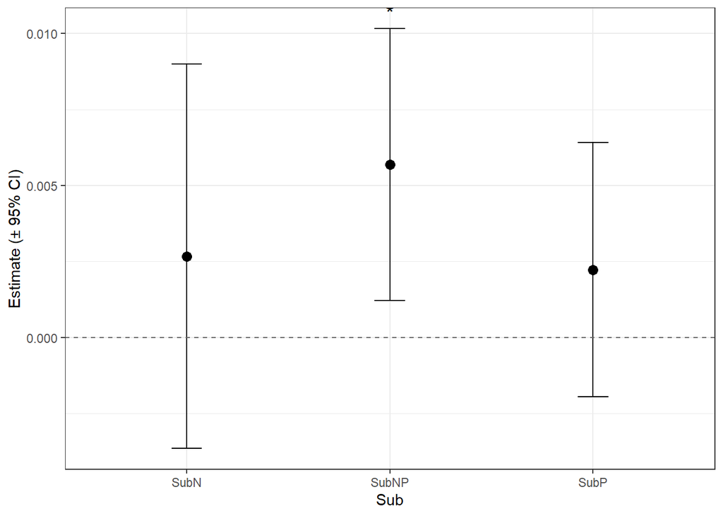

```r
library(ggplot2)
library(broom.mixed)
library(dplyr)

coefs <- tidy(
  mod_N_cr,
  effects = "fixed",
  conf.int = TRUE,
  conf.level = 0.95
) %>%
  filter(term != "(Intercept)")

coefs <- coefs %>%
  mutate(
    sig = case_when(
      p.value < 0.001 ~ "***",
      p.value < 0.01  ~ "**",
      p.value < 0.05  ~ "*",
      TRUE            ~ ""
    )
  )

ggplot(coefs, aes(x = term, y = estimate)) +
  geom_point(size = 3) +
  geom_errorbar(
    aes(ymin = conf.low, ymax = conf.high),
    width = 0.15
  ) +
  geom_text(
    aes(label = sig, y = conf.high),
    vjust = -0.6,
    size = 5)+
  geom_hline(yintercept = 0, linetype = "dashed", color = "grey40") +
  labs(
    x = "Sub",
    y = "Estimate (± 95% CI)"
  ) +
  theme_bw()
```

```r
coefs$term <- gsub("^Sub", "", coefs$term)

#library(dotwhisker)
#dwplot(mod_iWUE_pt, conf.level = 0.95) +
#  theme_bw()
```

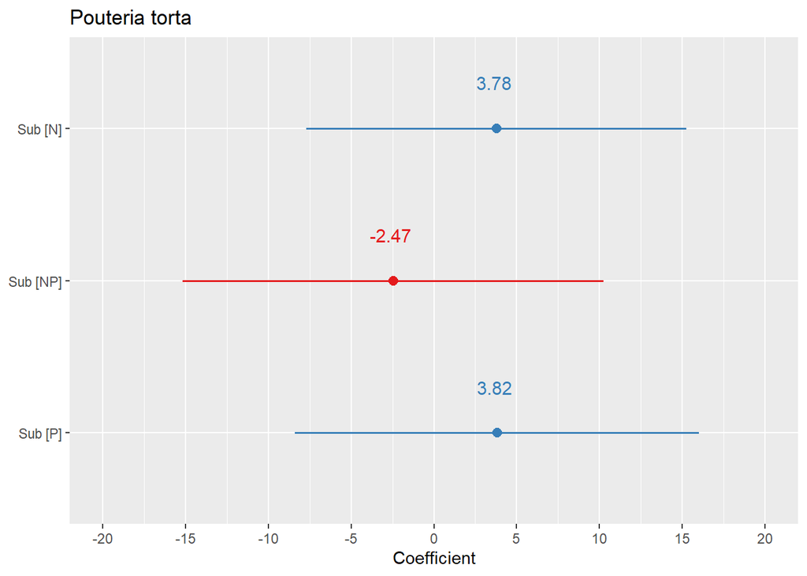

```r
plot_model(mod_iWUE_pt, title="Pouteria torta", axis.title="Coefficient", show.values = TRUE, value.offset = .3)
```

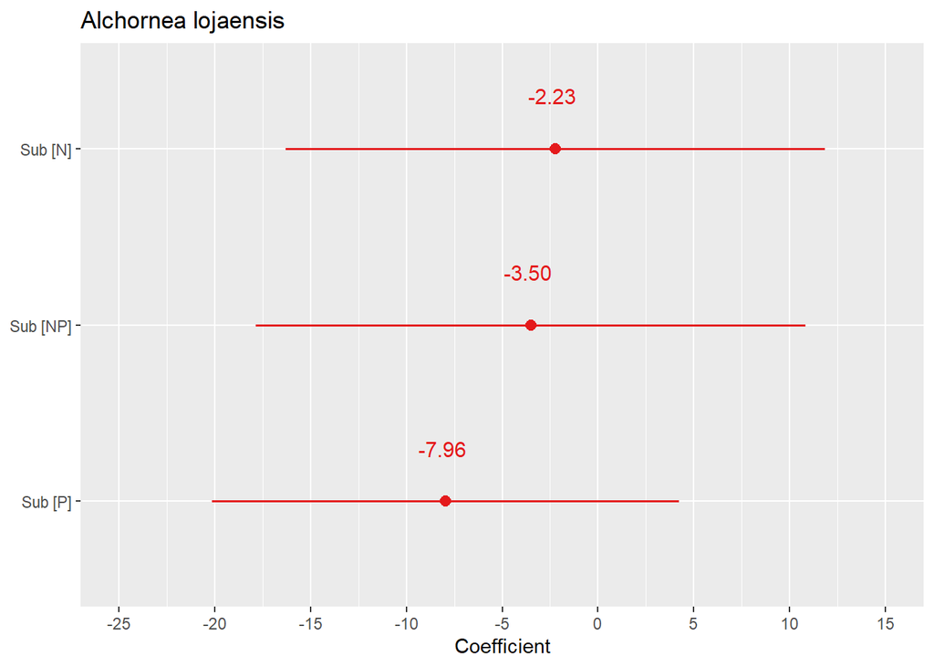

```r
plot_model(mod_iWUE_al, title="Alchornea lojaensis", axis.title="Coefficient", show.values = TRUE, value.offset = .3)
```

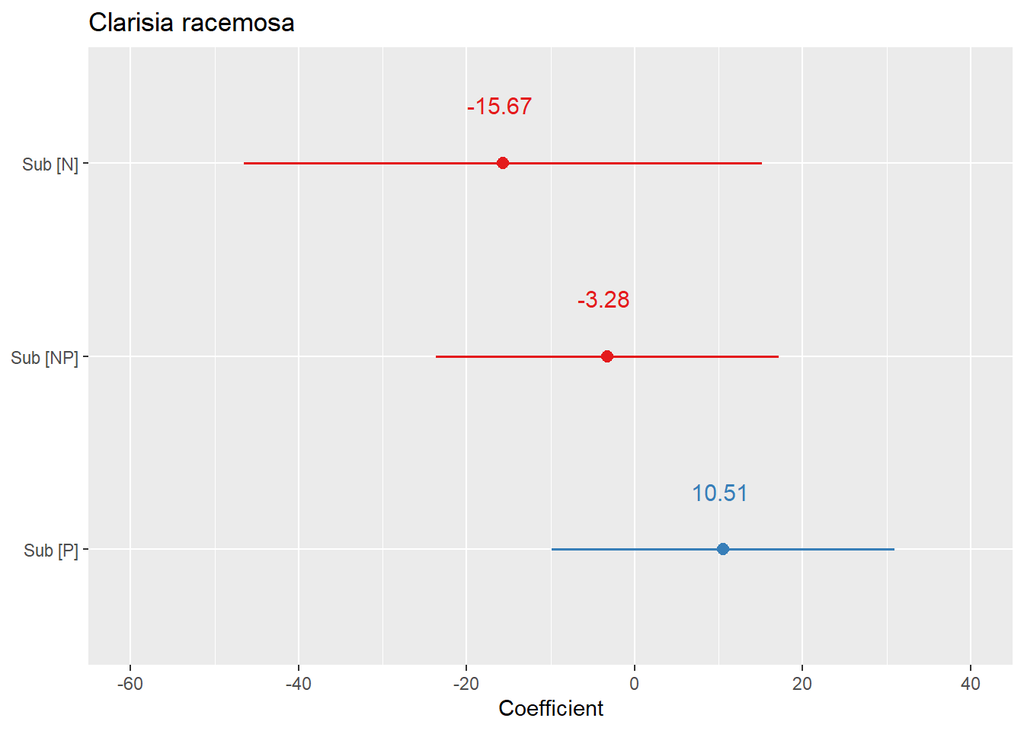

```r
plot_model(mod_iWUE_cr, title="Clarisia racemosa", axis.title="Coefficient", show.values = TRUE, value.offset = .3)
```

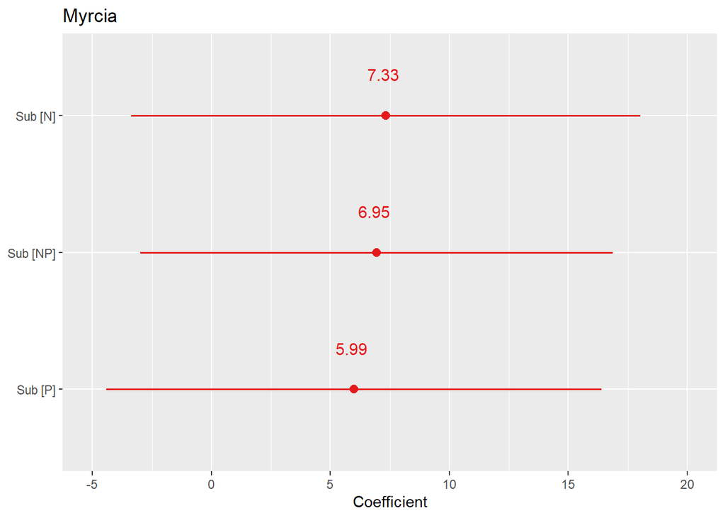

```r
plot_model(mod_iWUE_my, title="Myrcia", axis.title="Coefficient", show.values = TRUE, value.offset = .3)
```

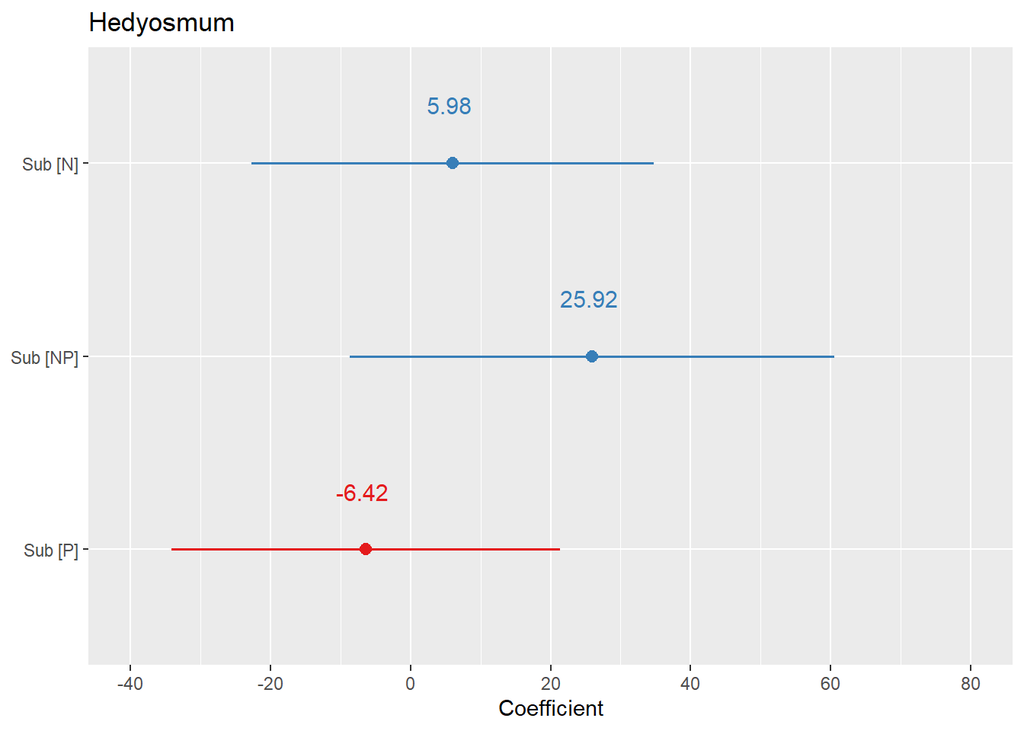

```r
plot_model(mod_iWUE_hp, title="Hedyosmum", axis.title="Coefficient", show.values = TRUE, value.offset = .3)
```

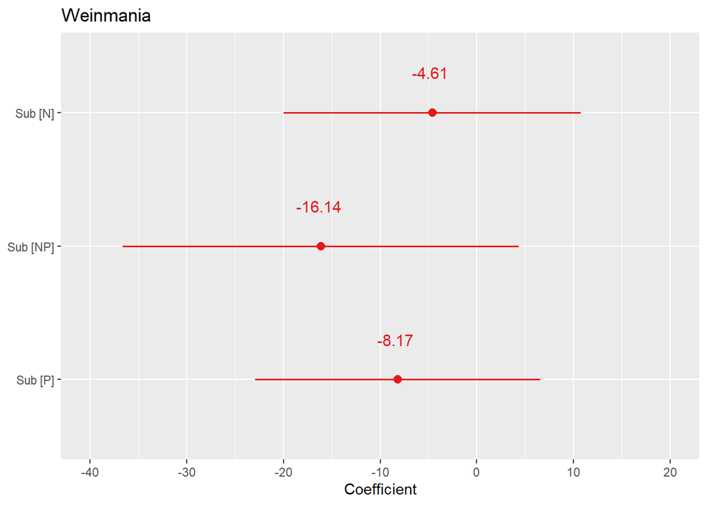

```r
plot_model(mod_iWUE_wl, title="Weinmania", axis.title="Coefficient", show.values = TRUE, value.offset = .3)
```

```r
plot_diagnostics <- function(model, model_name) {

  res <- residuals(model)#residual
  fit <- fitted(model) #model

  par(mfrow = c(1, 2)) #graph

  # Residuals vs Fitted
  plot(fit, res,
       xlab = "Fitted values",
       ylab = "Residuals",
       main = paste(model_name, "\nResiduals vs Fitted"))
  abline(h = 0, col = "red", lty = 2)

  # QQ plot
  qqnorm(res, main = paste(model_name, "\nNormal Q-Q"))
  qqline(res, col = "red", lty = 2)

  par(mfrow = c(1, 1))
}

#apply the plot_diagnostics_to_all
pdf("model_diagnostics_species.pdf", width = 10, height = 5)

for (nm in names(models)) {
  plot_diagnostics(models[[nm]], nm)
}

dev.off()
```

```
##
##  Pouteria iWUE
```

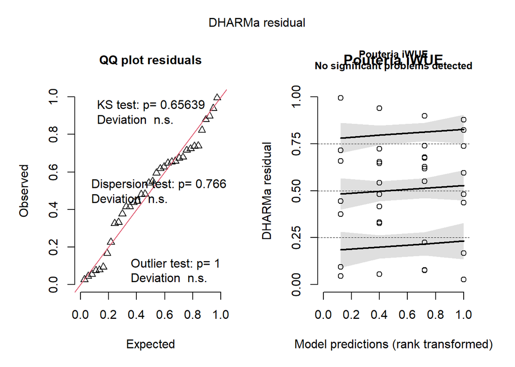

```
##
##  Pouteria O18
```

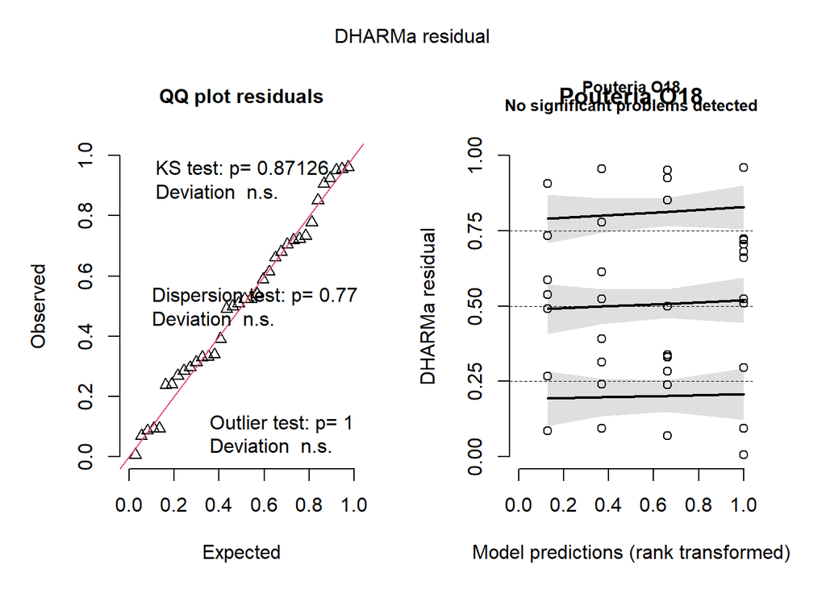

```
##
##  Pouteria Nmass
```

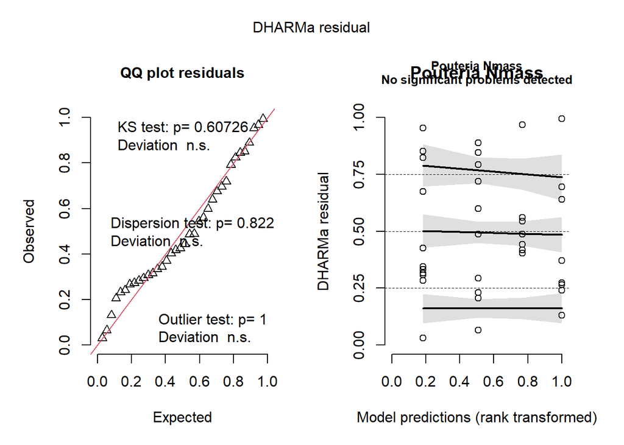

```
##
##  Pouteria Narea
```

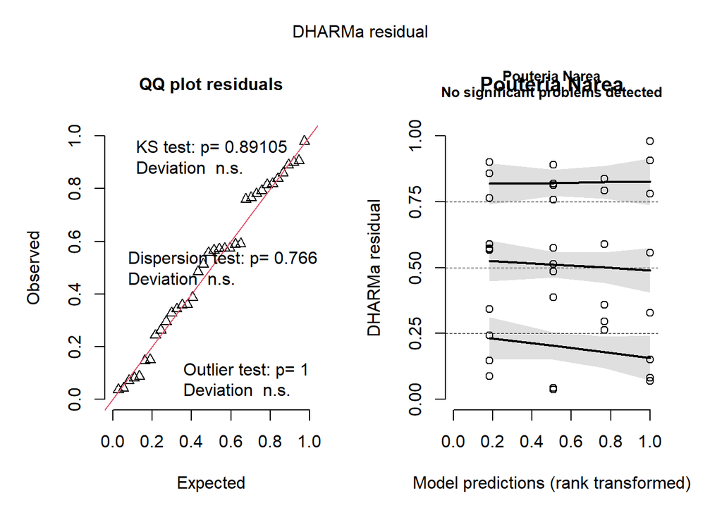

```
##
##  Pouteria logNmass
```

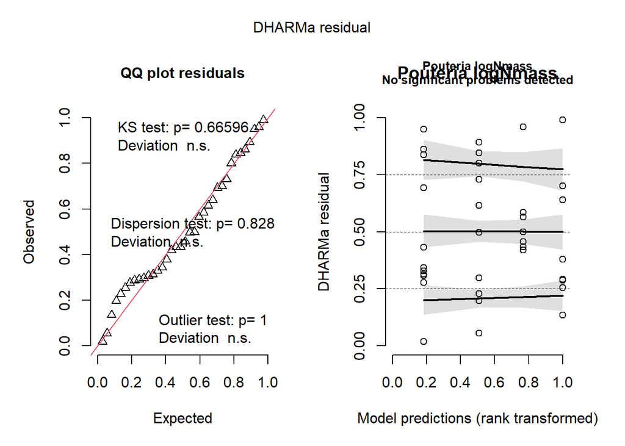

```
##
##  Pouteria logNarea
```

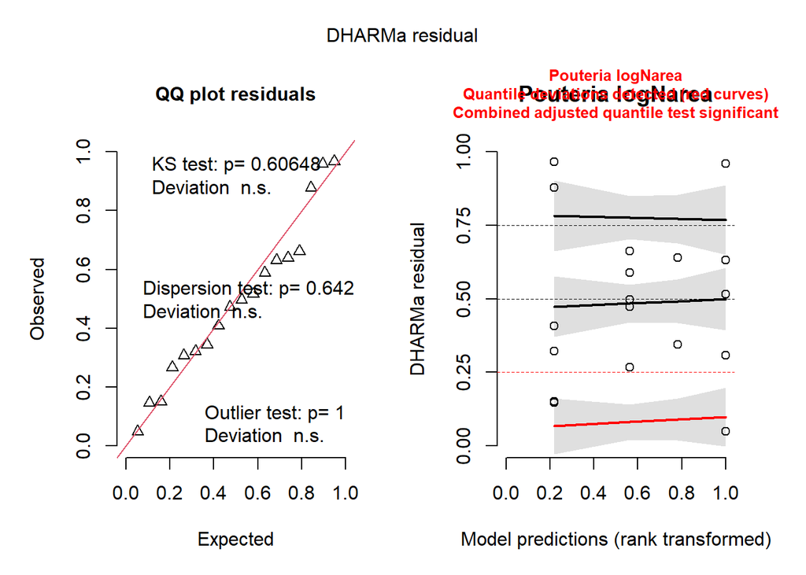

```
##
##  Clarisia iWUE
```

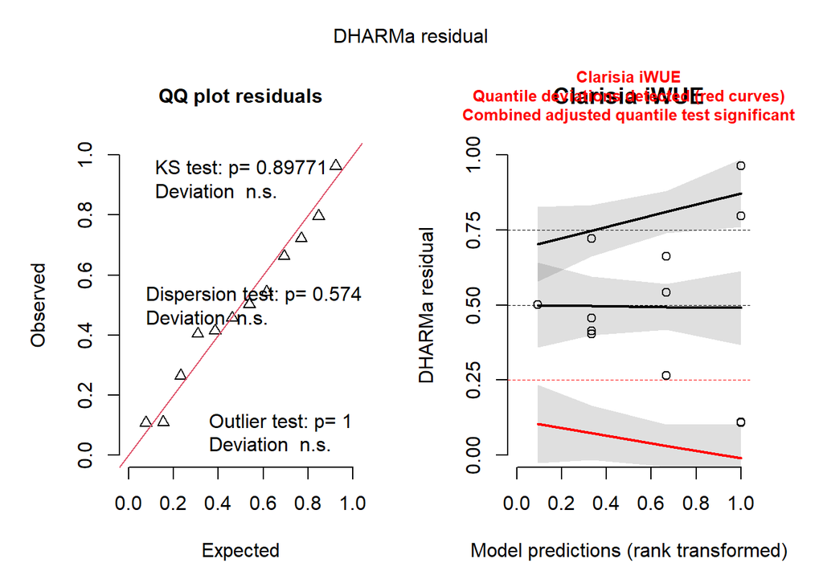

```
##
##  Clarisia O18
```

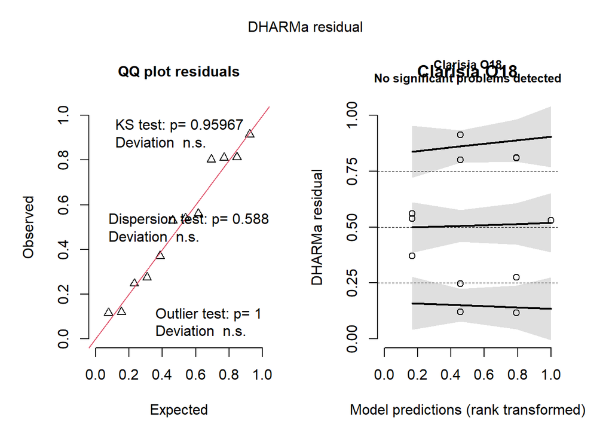

```
##
##  Clarisia Nmass
```

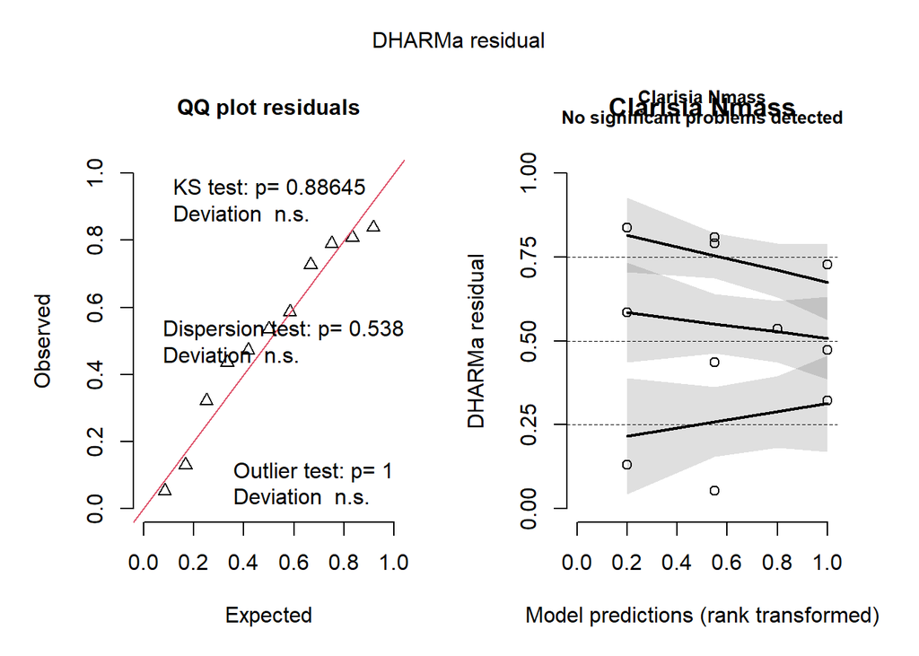

```
##
##  Clarisia Narea
```

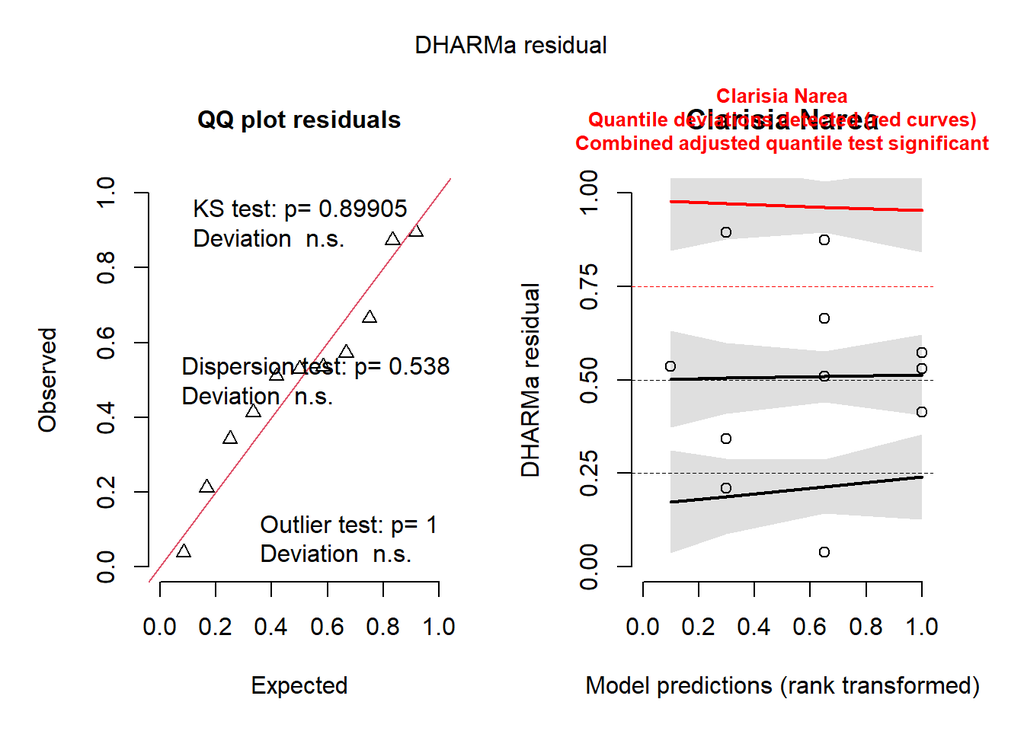

```
##
##  Clar logNmass
```

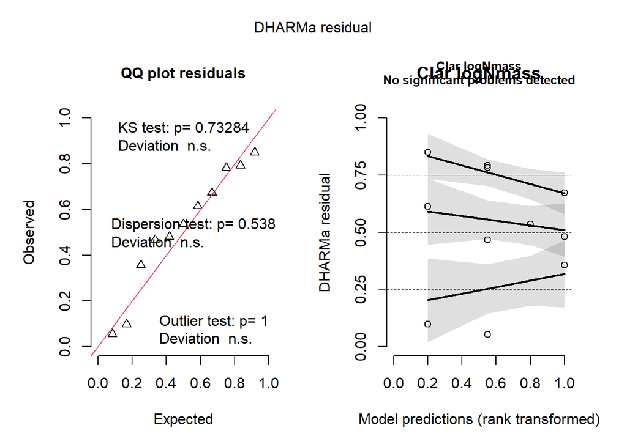

```
##
##  Clar logNarea
```

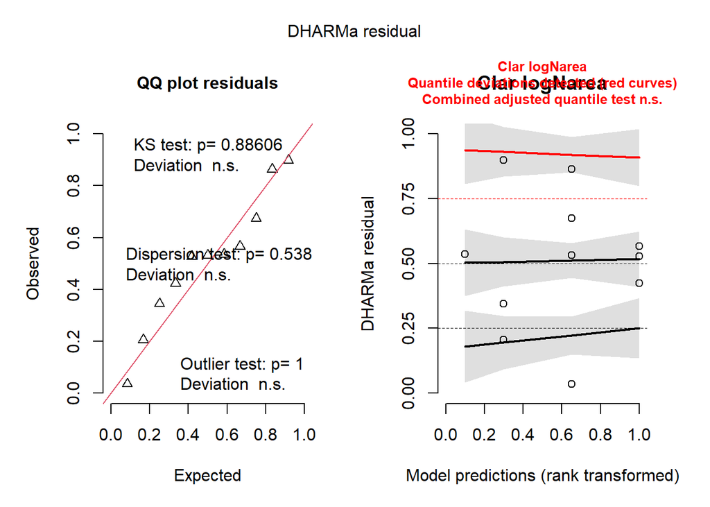

```
##
##  Alchornea iWUE
```

[24 more figures not shown]

```r
# Run and plot
for (nm in names(models)) {
  cat("\n", nm, "\n")
  res <- simulateResiduals(models[[nm]], n = 1000)
  plot(res, main = nm)
}
```

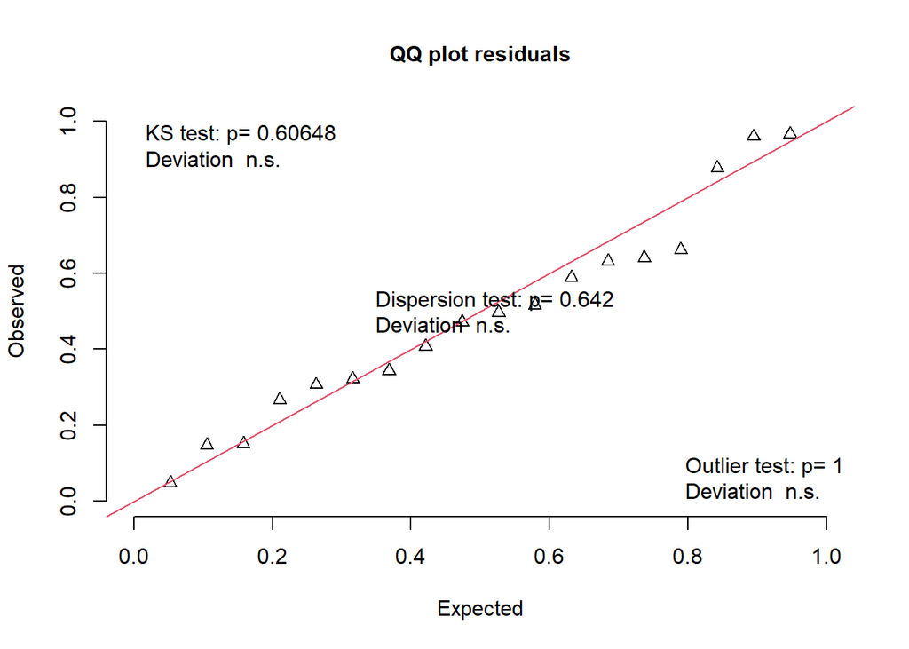

```
##
##  Exact one-sample Kolmogorov-Smirnov test
##
## data:  simulationOutput$scaledResiduals
## D = 0.17133, p-value = 0.6065
## alternative hypothesis: two-sided
```

```r
testUniformity(res)
```

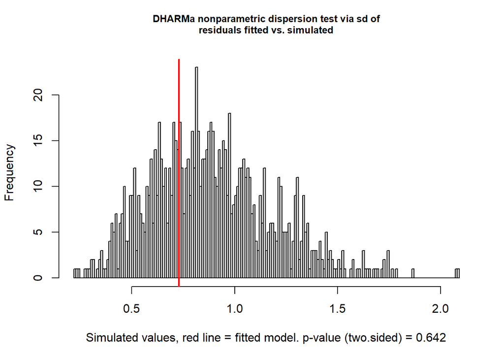

```
##
##  DHARMa nonparametric dispersion test via sd of residuals fitted vs.
##  simulated
##
## data:  simulationOutput
## dispersion = 0.81997, p-value = 0.642
## alternative hypothesis: two.sided
```

```r
testDispersion(res)
```

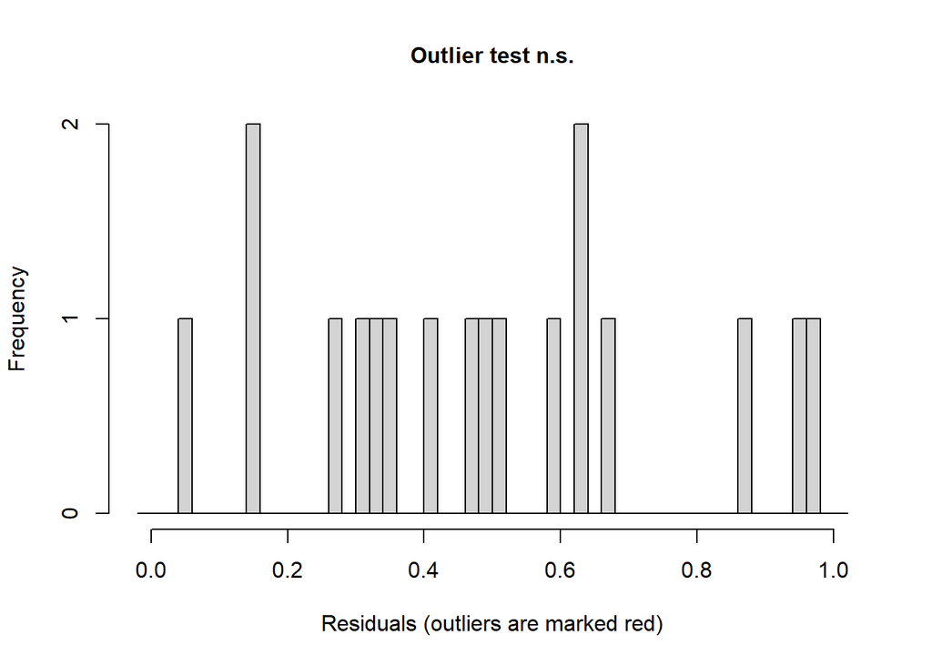

```
##
##  DHARMa outlier test based on exact binomial test with approximate
##  expectations
##
## data:  res
## outliers at both margin(s) = 0, observations = 18, p-value = 1
## alternative hypothesis: true probability of success is not equal to 0.001998002
## 95 percent confidence interval:
##  0.000000 0.185302
## sample estimates:
## frequency of outliers (expected: 0.001998001998002 )
##                                                    0
```

```r
testOutliers(res)
```

```r
pdf("DHARMa_diagnostics_species.pdf", width = 9, height = 7)

for (nm in names(models)) {
  res <- simulateResiduals(models[[nm]], n = 1000)
  plot(res, main = nm)
}

dev.off()
```